# Modelling Loss Curves in Insurance with RStan

Mick Cooney

2016-11-30

# 1 Model

## 1.1 Overview

$$g(t \, ; \; \theta, \omega) = \frac{t^\omega}{t^\omega + \theta^\omega}$$

$$g(t \, ; \; \theta, \omega) = 1 - \exp\left(-\left(\frac{t}{\theta}\right)^\omega\right)$$

# 2 Load Data

We will first look at the car insurance loss data from casact.org

```r
### File was downloaded from http://www.casact.org/research/reserve_data/ppauto_pos.csv

ppauto_dt <- fread("data/ppauto_pos.csv")

setnames(ppauto_dt, tolower(names(ppauto_dt)))

head(ppauto_dt)
```

```
##    grcode                  grname accidentyear developmentyear developmentlag
## 1:     43 IDS Property Cas Ins Co         1988            1988              1
## 2:     43 IDS Property Cas Ins Co         1988            1989              2
## 3:     43 IDS Property Cas Ins Co         1988            1990              3
## 4:     43 IDS Property Cas Ins Co         1988            1991              4
## 5:     43 IDS Property Cas Ins Co         1988            1992              5
## 6:     43 IDS Property Cas Ins Co         1988            1993              6
##    incurloss_b cumpaidloss_b bulkloss_b earnedpremdir_b earnedpremceded_b
## 1:         607           133        226             957                62
## 2:         647           333        129             957                62
## 3:         582           431         38             957                62
## 4:         598           570         19             957                62
## 5:         614           615          0             957                62
## 6:         615           615          0             957                62
##    earnedpremnet_b single postedreserve97_b
## 1:             895      0             73044
## 2:             895      0             73044
## 3:             895      0             73044
## 4:             895      0             73044
## 5:             895      0             73044
## 6:             895      0             73044
```

In terms of modeling the work, we want to ensure the data we work with is a snapshot in time.

```r
use_grcode <- c(43,388,620)[1]

snapshot_dt <- ppauto_dt %>%
    filter(grcode == use_grcode
          ,developmentyear < 1998) %>%
    mutate(acc_year   = accidentyear
          ,dev_lag    = developmentlag
          ,premium    = earnedpremdir_b
          ,cum_loss   = cumpaidloss_b
          ,loss_ratio = cum_loss / premium) %>%
    select(acc_year, dev_lag, premium, cum_loss, loss_ratio)
```

We look at the chain ladder of the data, rather than looking at the loss ratios we just look at the dollar amounts of the losses.

```r
snapshot_dt %>%
    select(acc_year, dev_lag, premium, cum_loss) %>%
    spread(dev_lag, cum_loss) %>%
    print
```

```
##     acc_year premium     1     2     3     4     5     6     7    8    9  10
##  1:     1988     957   133   333   431   570   615   615   615  614  614 614
##  2:     1989    3695   934  1746  2365  2579  2763  2966  2940 2978 2978  NA
##  3:     1990    6138  2030  4864  6880  8087  8595  8743  8763 8762   NA  NA
##  4:     1991   17533  4537 11527 15123 16656 17321 18076 18308   NA   NA  NA
##  5:     1992   29341  7564 16061 22465 25204 26517 27124    NA   NA   NA  NA
##  6:     1993   37194  8343 19900 26732 30079 31249    NA    NA   NA   NA  NA
##  7:     1994   46095 12565 26922 33867 38338    NA    NA    NA   NA   NA  NA
##  8:     1995   51512 13437 26012 31677    NA    NA    NA    NA   NA   NA  NA
##  9:     1996   52481 12604 23446    NA    NA    NA    NA    NA   NA   NA  NA
## 10:     1997   56978 12292    NA    NA    NA    NA    NA    NA   NA   NA  NA
```

We also look at the loss ratios in a similar fashion

```r
snapshot_dt %>%
    select(acc_year, dev_lag, premium, loss_ratio) %>%
    spread(dev_lag, loss_ratio) %>%
    print(digits = 2)
```

```
##     acc_year premium    1    2    3    4    5    6    7    8    9   10
##  1:     1988     957 0.14 0.35 0.45 0.60 0.64 0.64 0.64 0.64 0.64 0.64
##  2:     1989    3695 0.25 0.47 0.64 0.70 0.75 0.80 0.80 0.81 0.81   NA
##  3:     1990    6138 0.33 0.79 1.12 1.32 1.40 1.42 1.43 1.43   NA   NA
##  4:     1991   17533 0.26 0.66 0.86 0.95 0.99 1.03 1.04   NA   NA   NA
##  5:     1992   29341 0.26 0.55 0.77 0.86 0.90 0.92   NA   NA   NA   NA
##  6:     1993   37194 0.22 0.54 0.72 0.81 0.84   NA   NA   NA   NA   NA
##  7:     1994   46095 0.27 0.58 0.73 0.83   NA   NA   NA   NA   NA   NA
##  8:     1995   51512 0.26 0.50 0.61   NA   NA   NA   NA   NA   NA   NA
##  9:     1996   52481 0.24 0.45   NA   NA   NA   NA   NA   NA   NA   NA
## 10:     1997   56978 0.22   NA   NA   NA   NA   NA   NA   NA   NA   NA
```

## 2.1 Quick Data Exploration

We are working with the loss ratio, so we recreate the chain ladder format but look at loss ratios instead of dollar losses.

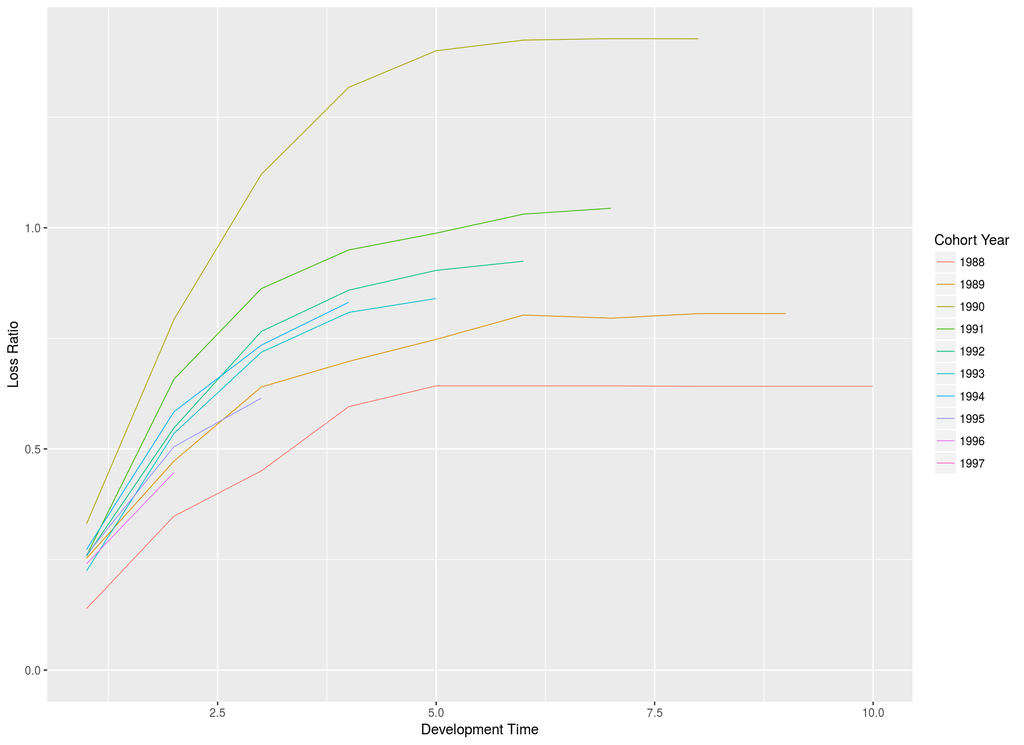

```r
ggplot() +
    geom_line(aes(x = dev_lag, y = loss_ratio, colour = as.character(acc_year))
             ,data = snapshot_dt
             ,size = 0.3) +
    expand_limits(y = 0) +
    xlab('Development Time') +
    ylab('Loss Ratio') +
    guides(colour = guide_legend(title = 'Cohort Year'))
```

# 3 Stan Model

## 3.1 Configure Data

We want to only use the data at a given snapshot, so we choose all data current to 1998. Thus, we have 10 years of development for our first 1988 cohort, and one less for each subsequent year. Our final cohort for 1997 has only a single year of development

```r
cohort_dt <- snapshot_dt %>%
    select(acc_year, premium) %>%
    unique() %>%
    mutate(cohort_id = 1:n())

usedata_dt <- snapshot_dt

cohort_maxtime <- usedata_dt %>%
    group_by(acc_year) %>%
    summarise(maxtime = max(dev_lag)) %>%
    arrange(acc_year) %>%
    .[[2]]

cohort_premium <- usedata_dt %>%
    group_by(acc_year) %>%
    summarise(premium = unique(premium)) %>%
    .[[2]]

standata_lst <- list(growthmodel_id = 1   # Use weibull rather than loglogistic
                    ,n_data         = usedata_dt %>% nrow
                    ,n_time         = usedata_dt %>% select(dev_lag)  %>% unique %>% nrow
                    ,n_cohort       = usedata_dt %>% select(acc_year) %>% unique %>% nrow
                    ,cohort_id      = get_character_index(usedata_dt$acc_year)
                    ,cohort_maxtime = cohort_maxtime
                    ,t_value        = usedata_dt %>% select(dev_lag) %>% arrange(dev_lag) %>% unique %>% .[[1]]
                    ,t_idx          = get_character_index(usedata_dt$dev_lag)
                    ,premium        = cohort_premium
                    ,loss           = usedata_dt$cum_loss
                    )
```

The full Stan file is shown below:

```
functions {
    real growth_factor_weibull(real t, real omega, real theta) {
        real factor;

        factor = 1 - exp(-(t/theta)^omega);

        return(factor);
    }

    real growth_factor_loglogistic(real t, real omega, real theta) {
        real factor;

        factor = ((t^omega) / (t^omega + theta^omega));

        return(factor);
    }
}

data {
    int<lower=0,upper=1> growthmodel_id;

    int n_data;
    int n_time;
    int n_cohort;

    int cohort_id[n_data];
    int t_idx[n_data];

    int cohort_maxtime[n_cohort];

    real<lower=0> t_value[n_time];

    real premium[n_cohort];
    real loss[n_data];
}

parameters {
    real<lower=0> omega;
    real<lower=0> theta;

    real<lower=0> LR[n_cohort];

    real mu_LR;
    real<lower=0> sd_LR;

    real<lower=0> loss_sd;
}

transformed parameters {
    real gf[n_time];
    real loss_mean[n_cohort, n_time];

    for(i in 1:n_time) {
        if(growthmodel_id == 1) {
            gf[i] = growth_factor_weibull    (t_value[i], omega, theta);
        } else {
            gf[i] = growth_factor_loglogistic(t_value[i], omega, theta);
        }
    }

    for(i in 1:n_data) {
        loss_mean[cohort_id[i], t_idx[i]] = LR[cohort_id[i]] * premium[cohort_id[i]] * gf[t_idx[i]];
    }
}

model {
    mu_LR ~ normal(0, 0.5);
    sd_LR ~ lognormal(0, 0.5);

    LR ~ lognormal(mu_LR, sd_LR);

    loss_sd ~ lognormal(0, 0.7);

    omega ~ lognormal(0, 1);
    theta ~ lognormal(0, 1);

    for(i in 1:n_data) {
        loss[i] ~ normal(loss_mean[cohort_id[i], t_idx[i]], premium[cohort_id[i]] * loss_sd);
    }
}


generated quantities {
    real mu_LR_exp;
    real<lower=0> loss_sample[n_cohort, n_time];
    real<lower=0> loss_prediction[n_cohort, n_time];
    real<lower=0> step_ratio[n_cohort, n_time];

    for(i in 1:n_cohort) {
        for(j in 1:n_time) {
            loss_sample[i, j] = LR[i] * premium[i] * gf[t_idx[j]];
            step_ratio [i, j] = 1.0;
        }
    }

    mu_LR_exp = exp(mu_LR);

    for(i in 1:n_data) {
        loss_prediction[cohort_id[i], t_idx[i]] = loss[i];
    }

    for(i in 1:n_cohort) {
        for(j in 2:n_time) {
            step_ratio[i, j] = gf[t_idx[j]] / gf[t_idx[j-1]];
        }
    }

    for(i in 1:n_cohort) {
        for(j in (cohort_maxtime[i]+1):n_time) {
            loss_prediction[i,j] = loss_prediction[i,j-1] * step_ratio[i,j];
        }
    }
}
```

Need to discuss a number of issues with the above file:

- Use of functions to select between the Weibull and Loglogistic
- Use of lognormal to ensure positive values on LR and stddevs
- Use of normal, not lognormal, for mu_LR as it feeds into a lognormal
- Use of generated quantities

```r
lc_1_stanfit <- stan(file   = 'losscurves_single.stan'
                    ,data   = standata_lst
                    ,iter   = 500
                    ,chains = 8
                    )
```

It is always worth checking convergence of the model by checking the $\hat{R}$ and ensuring it is less than about 1.1

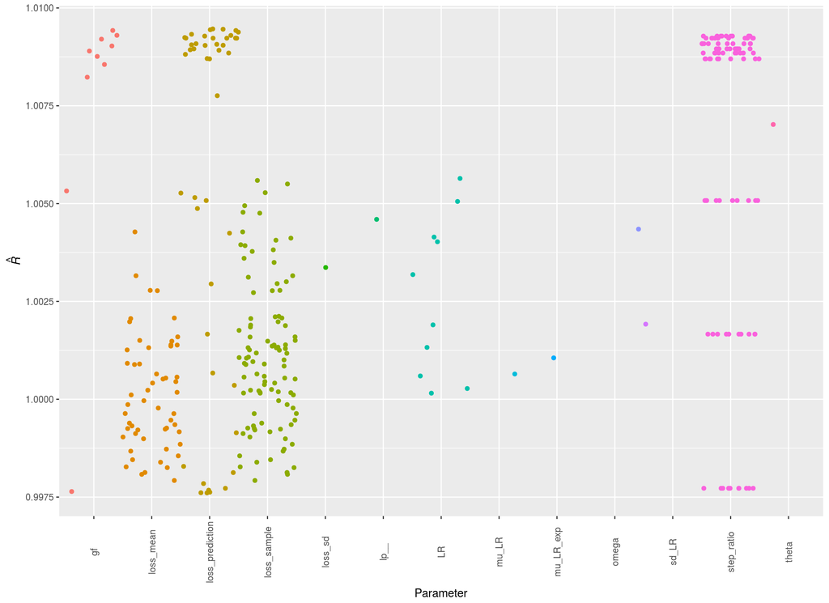

```r
# Plot of convergence statistics
lc_1_draws   <- extract(lc_1_stanfit, permuted = FALSE, inc_warmup = TRUE)
lc_1_monitor <- as.data.frame(monitor(lc_1_draws, print = FALSE))
lc_1_monitor$Parameter <- as.factor(gsub("\\[.*]", "", rownames(lc_1_monitor)))

ggplot(lc_1_monitor) +
    aes(x = Parameter, y = Rhat, color = Parameter) +
    geom_jitter(height = 0, width = 0.5, show.legend = FALSE) +
    theme(axis.text.x = element_text(angle = 90, vjust = 0.5)) +
    ylab(expression(hat(italic(R))))
```

```r
param_root <- c("omega", "theta", "LR", "gf", "loss_sd")

use_vars <- unlist(lapply(param_root
    ,function(iterstr) rownames(lc_1_monitor)[grep(iterstr, rownames(lc_1_monitor))]))
```

Check the traces. There are a large number of parameters in this model fit, so we break them up into groups. First we look at `omega`, `theta` and `LR`

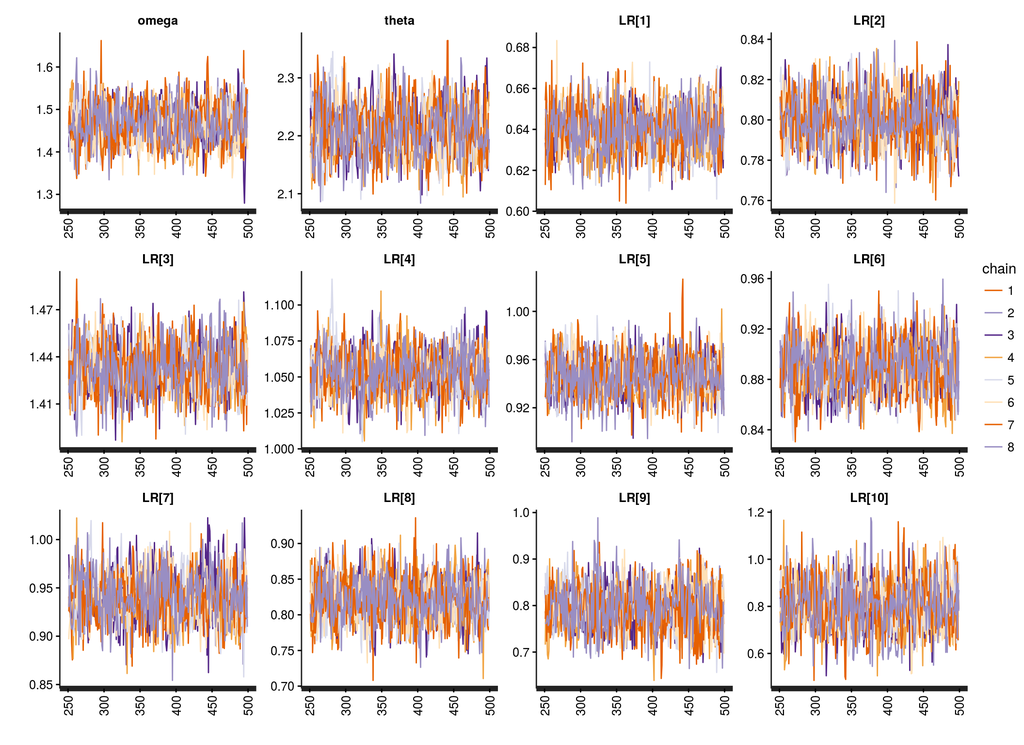

```r
rstan::traceplot(lc_1_stanfit, pars = c("omega","theta","LR")) +
    theme(axis.text.x = element_text(angle = 90, vjust = 0.5))
```

Now we look at the traces for `gf` and `loss_sd`.

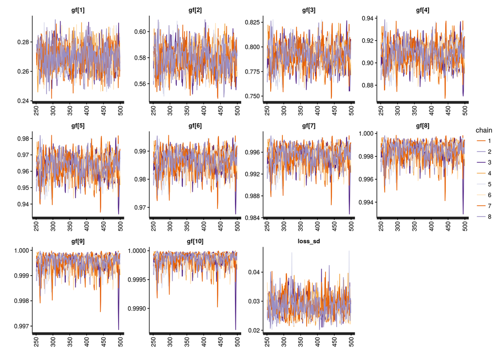

```r
rstan::traceplot(lc_1_stanfit, pars = c("gf","loss_sd")) +
    theme(axis.text.x = element_text(angle = 90, vjust = 0.5))
```

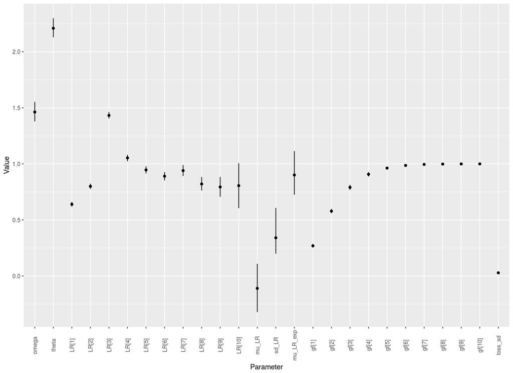

```r
plotdata_dt <- lc_1_monitor[use_vars, c('mean', '2.5%', '50%', '97.5%')] %>%
    mutate(variable = factor(use_vars, levels = use_vars))

ggplot(plotdata_dt) +
    geom_point(aes(x = variable, y = mean)) +
    geom_errorbar(aes(x = variable, y = mean, ymin = `2.5%`, ymax = `97.5%`), width = 0) +
    expand_limits(y = 0) +
    theme(axis.text.x = element_text(angle = 90, vjust = 0.5)) +
    xlab("Parameter") +
    ylab("Value")
```

## 3.2 SolvencyII and the 99.5 Percentile